# Assignment 13: Writing a function - Conditional Statement

*How to do it?*:

- Open the Rmarkdown file of this assignment (link) in Rstudio.
- Right under each **question**, insert a code chunk (you can use the hotkey `Ctrl + Alt + I` to add a code chunk) and code the solution for the question.
- `Knit` the rmarkdown file (hotkey: `Ctrl + Alt + K`) to export an html.
- Publish the html file to your Githiub Page.

*Submission*: Submit the link on Github of the assignment to Canvas

#### NOTICE: Question 7, 8 and 9 are optional.

1. Write a function to calculate the age of a person. Give an example to test your function.
- Input: a number, x, (year born)
- Output: Print out “You are r age”. Where r is the age of the person, i.e. 2020 - x.

Hint: [Similar Function](https://bryantstats.github.io/math421/gganimate/17_writing_functions.html#42)

```r
person_age <- function(x) {
  age <- 2020 - x
  print(paste("You are", age))
}

person_age(2000)
```

```
## [1] "You are 20"
```

```r
person_age(1995)
```

```
## [1] "You are 25"
```

The examples print ages 20 and 25. I use 2020 as the reference year because the question specifically asks for `2020 - x`.

2. Write the following function. Give an example to test your function.
- Input: a number
- Output: print out: “You input an even number!” if the number is event, or “You input an odd number!” otherwise.

Hint: [Similar Function](https://bryantstats.github.io/math421/gganimate/17_writing_functions.html#46)

```r
even_or_odd <- function(x) {
  if (x %% 1 != 0) {
    stop("Enter a whole number.")
  }
  if (x %% 2 == 0) {
    print("You input an even number!")
  } else {
    print("You input an odd number!")
  }
}

even_or_odd(8)
```

```
## [1] "You input an even number!"
```

```r
even_or_odd(7)
```

```
## [1] "You input an odd number!"
```

```r
even_or_odd(0)
```

```
## [1] "You input an even number!"
```

```r
even_or_odd(-3)
```

```
## [1] "You input an odd number!"
```

`%%` gives the remainder after division. A whole number is even when its remainder after division by two is zero. The examples check even, odd, zero, and negative inputs.

3. Write the following function. Give an example to test your function.
- Input: a numeric vector
- Output:
  - if the input vector has missing values: return the input vector with missing values replaced by mean
  - if the input vector has no missing value: return the same input vector

Hint: [Similar Function](https://bryantstats.github.io/math421/gganimate/17_writing_functions.html#50)

```r
mean_impute <- function(x) {
  if (!is.numeric(x)) {
    stop("Input must be a numeric vector.")
  }
  if (any(is.na(x))) {
    if (all(is.na(x))) {
      stop("At least one observed value is needed to calculate a mean.")
    }
    x[is.na(x)] <- mean(x, na.rm = TRUE)
  }
  return(x)
}

mean_impute(c(10, 20, NA, 30))
```

```
## [1] 10 20 20 30
```

```r
mean_impute(c(10, 20, 30))
```

```
## [1] 10 20 30
```

The first result is `10, 20, 20, 30`. The missing entry is replaced by the mean of the observed values. The second input has no missing values and is returned unchanged. If all entries are missing, there is no observed mean, so the function gives an explanatory error.

4. Write the following function. Give an example to test your function.
- Input: a vector x
- Output: The vector x where the missing values replaced by the mean (if x is numeric) or the mode (if x is non-numeric). If x does not have missing value, return the same vector x.

Hint: Use If-statement to combine the function in Question 3 and [this function](https://bryantstats.github.io/math421/gganimate/17_writing_functions.html#49)

```r
impute_missing <- function(x) {
  if (any(is.na(x))) {
    if (all(is.na(x))) {
      stop("At least one observed value is needed for imputation.")
    }
    if (is.numeric(x)) {
      x <- mean_impute(x)
    } else {
      # Find the most frequent observed value, as in the slides.
      mode_of_x <- names(sort(table(x), decreasing = TRUE))[1]
      # Take that value from x to preserve its type, including factors.
      replacement <- x[match(mode_of_x, as.character(x))]
      x[is.na(x)] <- replacement
    }
  }
  return(x)
}

impute_missing(c(5, NA, 15))
```

```
## [1]  5 10 15
```

```r
impute_missing(c("red", NA, "blue", "red"))
```

```
## [1] "red"  "red"  "blue" "red"
```

```r
impute_missing(factor(c("yes", NA, "no", "yes")))
```

```
## [1] yes yes no  yes
## Levels: no yes
```

```r
impute_missing(c(TRUE, NA, TRUE, FALSE))
```

```
## [1]  TRUE  TRUE  TRUE FALSE
```

```r
impute_missing(c("red", "blue"))
```

```
## [1] "red"  "blue"
```

Numeric missing values are replaced by the observed mean. Non-numeric missing values are replaced by the mode, or most frequent observed value. The examples also show that factor and logical inputs keep their types. When modes tie, the first tied category in the table’s order is used. Inputs without missing values are returned unchanged.

5. Write the following function. Give examples to test your function.
- Input: A data frame of two variables x and y
- Output:
  - A boxplot of x by y if x is numeric and y is non-numeric
  - A boxplot of y by x if y is numeric and x is non-numeric
  - print out ‘This function cannot visualize your data’ otherwise

Hint:

- [Similar Function](https://bryantstats.github.io/math421/gganimate/17_writing_functions.html#53)
- You can refer to this slide to plot a boxplot: https://bryantstats.github.io/math421/slides/6_viz.html#36

```r
boxplot_two <- function(d) {
  if (ncol(d) != 2) {
    stop("Provide a data frame with exactly two columns.")
  }
  if (is.numeric(d[[1]]) && !is.numeric(d[[2]])) {
    p <- ggplot(d, aes(x = d[[2]], y = d[[1]])) +
      geom_boxplot(fill = "steelblue") +
      labs(title = paste(names(d)[1], "by", names(d)[2]),
           x = names(d)[2], y = names(d)[1],
           caption = "Boxes show the middle 50% of values; the line is the median.")
    return(p)
  } else if (!is.numeric(d[[1]]) && is.numeric(d[[2]])) {
    p <- ggplot(d, aes(x = d[[1]], y = d[[2]])) +
      geom_boxplot(fill = "steelblue") +
      labs(title = paste(names(d)[2], "by", names(d)[1]),
           x = names(d)[1], y = names(d)[2],
           caption = "Boxes show the middle 50% of values; the line is the median.")
    return(p)
  } else {
    print("This function cannot visualize your data")
  }
}

# The built-in mtcars data need no separate download.
car_data <- mtcars %>%
  mutate(cyl = factor(cyl),
         am = factor(am, levels = c(0, 1), labels = c("Automatic", "Manual")))

# One numeric and one categorical variable, in both column orders.
boxplot_two(car_data %>% select(mpg, cyl))
```

[output not shown]

```r
boxplot_two(car_data %>% select(cyl, mpg))
```

[output not shown]

```r
# Neither of these pairs is suitable for this boxplot function.
boxplot_two(car_data %>% select(wt, mpg))
```

```
## [1] "This function cannot visualize your data"
```

```r
boxplot_two(car_data %>% select(cyl, am))
```

```
## [1] "This function cannot visualize your data"
```

6. Combine the function in Question 5 and the function in this example ([Link](https://bryantstats.github.io/math421/gganimate/17_writing_functions.html#53)) to have a function that can plot all possible cases (2 categorical, 2 numeric, 1 numeric and 1 categorical).

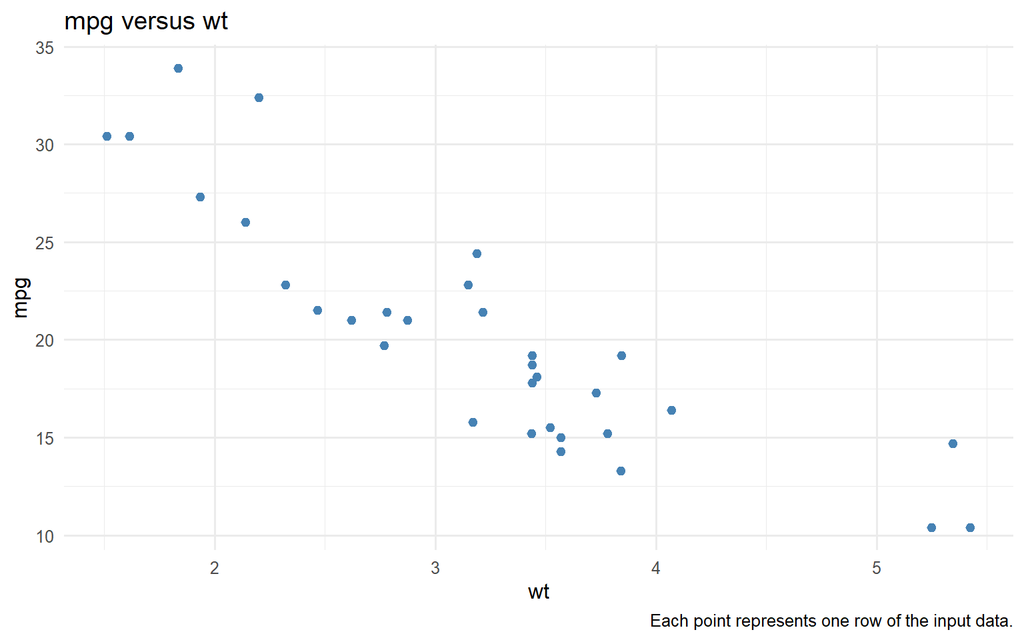

```r
plot_two <- function(d) {
  if (ncol(d) != 2) {
    stop("Provide a data frame with exactly two columns.")
  }
  if (is.numeric(d[[1]]) && is.numeric(d[[2]])) {
    p <- ggplot(d, aes(x = d[[1]], y = d[[2]])) +
      geom_point(color = "steelblue", size = 2) +
      labs(title = paste(names(d)[2], "versus", names(d)[1]),
           x = names(d)[1], y = names(d)[2],
           caption = "Each point represents one row of the input data.")
    return(p)
  } else if (!is.numeric(d[[1]]) && !is.numeric(d[[2]])) {
    p <- ggplot(d, aes(x = d[[1]], fill = d[[2]])) +
      geom_bar(position = "dodge") +
      labs(title = paste(names(d)[1], "by", names(d)[2]),
           x = names(d)[1], y = "Count", fill = names(d)[2],
           caption = "Bars count rows in each combination of categories.")
    return(p)
  } else {
    return(boxplot_two(d))
  }
}

# Two numeric variables: scatterplot.
plot_two(car_data %>% select(wt, mpg))
```

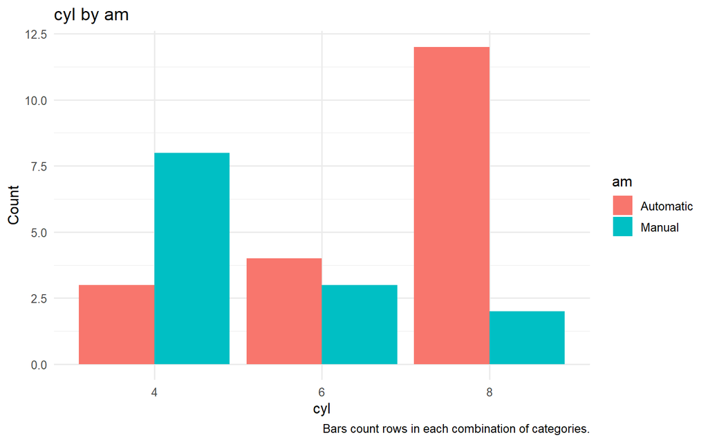

```r
# Two categorical variables: grouped bar chart.
plot_two(car_data %>% select(cyl, am))
```

```r
# One numeric and one categorical variable: boxplot in either order.
plot_two(car_data %>% select(mpg, cyl))
```

[output not shown]

```r
plot_two(car_data %>% select(cyl, mpg))
```

[output not shown]

The function checks the two column types with `is.numeric()`. It uses a scatterplot for two numeric columns, a grouped bar chart for two categorical columns, and the function from Question 5 for either mixed ordering.

#### NOTICE: Question 7, 8 and 9 are optional.

7. Write the following function. Give examples to test your function.
- Input:
  - input_data: a clean data frame with a variable name `target`. The `target` variable is also binary.
  - train_percent: a number presenting a proportion of training data. The default train_percent is .8
- Output: the accuracy of the decision model `rpart` where the training data is train_percent.

```r
tree_accuracy <- function(input_data, train_percent = .8) {
  stopifnot("target" %in% names(input_data), !anyNA(input_data),
            train_percent > 0, train_percent < 1)
  input_data <- input_data %>%
    mutate(across(where(is.character), as.factor), target = factor(target))
  stopifnot(nlevels(input_data$target) == 2)

  set.seed(421)
  splitIndex <- createDataPartition(input_data$target, p = train_percent,
                                    list = FALSE)
  df_train <- input_data[splitIndex, ]
  df_test <- input_data[-splitIndex, ]

  tree_model <- rpart(target ~ ., data = df_train, method = "class")
  pred <- predict(tree_model, df_test, type = "class")
  cm <- confusionMatrix(data = pred, reference = df_test$target,
                         positive = levels(input_data$target)[2])
  return(unname(cm$overall["Accuracy"]))
}

# Retain two species so the built-in iris example has a binary target.
iris_binary <- iris %>%
  filter(Species != "setosa") %>%
  rename(target = Species) %>%
  mutate(target = droplevels(target))

accuracy_80 <- tree_accuracy(iris_binary)
accuracy_70 <- tree_accuracy(iris_binary, train_percent = .7)

knitr::kable(data.frame(
  Training_proportion = c(.8, .7),
  Testing_accuracy = c(accuracy_80, accuracy_70)
), digits = 3)
```

| Training_proportion | Testing_accuracy |
| --- | --- |
| 0.8 | 0.85 |
| 0.7 | 0.90 |

Omitting `train_percent` uses its default of 0.8. The second call supplies 0.7 instead. The output is the proportion of testing records classified correctly. These are small examples to demonstrate the function; the different testing sets mean the scores are not a controlled comparison of training proportions.

8. Write the following function. Give examples to test your function.
- Input:
  - input_data: a clean data frame with a variable name `target`. The `target` variable is also binary.
  - train_percent: a number presenting a proportion of training data. The default train_percent is .8
- Output: the plot of variable important by random forest trained by caret.

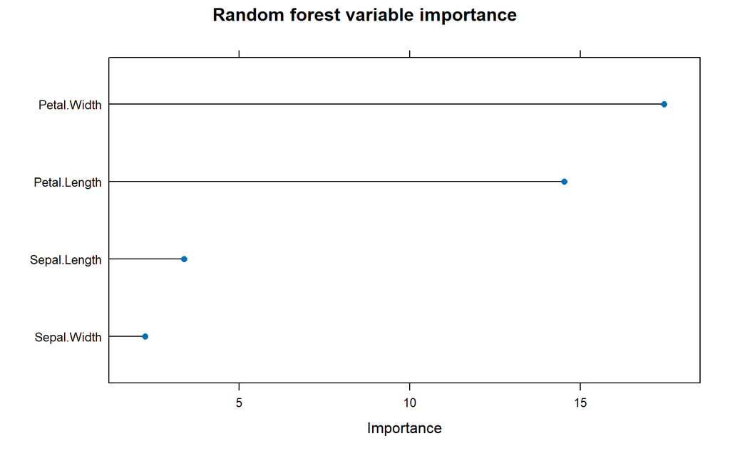

```r
forest_importance <- function(input_data, train_percent = .8) {
  stopifnot("target" %in% names(input_data), !anyNA(input_data),
            train_percent > 0, train_percent < 1)
  input_data <- input_data %>%
    mutate(across(where(is.character), as.factor), target = factor(target))
  stopifnot(nlevels(input_data$target) == 2)

  set.seed(421)
  splitIndex <- createDataPartition(input_data$target, p = train_percent,
                                    list = FALSE)
  df_train <- input_data[splitIndex, ]

  ctrl <- trainControl(method = "cv", number = 5, allowParallel = FALSE)
  forest_model <- train(
    target ~ ., data = df_train, method = "ranger", trControl = ctrl,
    tuneGrid = expand.grid(mtry = c(1, 2), splitrule = "gini", min.node.size = 5),
    num.trees = 300, num.threads = 1, importance = "impurity"
  )
  importance_plot <- plot(varImp(forest_model, scale = FALSE),
                           main = "Random forest variable importance")
  return(importance_plot)
}

forest_importance(iris_binary)
```

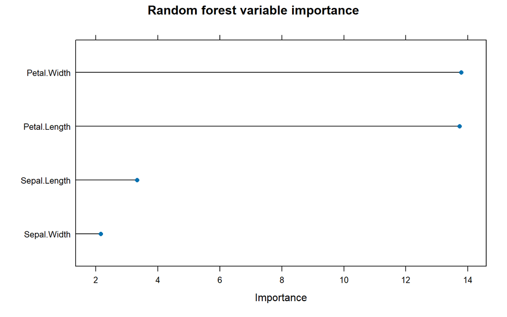

```r
forest_importance(iris_binary, train_percent = .7)
```

The function uses caret’s `train()` with `method = "ranger"` to fit a random forest. Five-fold cross-validation happens within the training portion. The returned plot ranks predictor importance for the fitted forest. Importance shows predictive use and does not establish causation.

9. Write the following function. Give examples to test your function.
- Input:
  - a data frame that has a text column
  - the name of the text column in the data
- Output: the word cloud plot of the text column

Sample codes

- [Word Cloud codes](https://bryantstats.github.io/math421/assignments/text_mining_sample_codes2.html#Total_Word_Cloud)
- [A similar function](https://bryantstats.github.io/math421/gganimate/17_writing_functions.html#10)

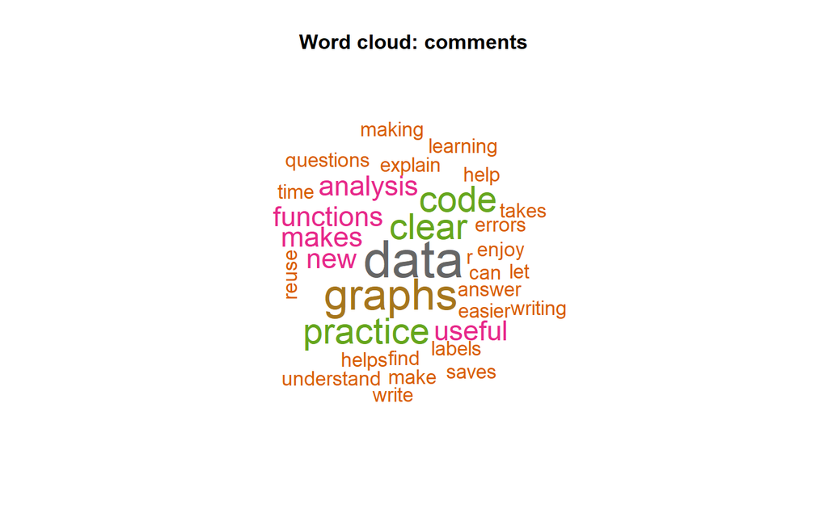

```r
text_wordcloud <- function(input_data, text_col) {
  stopifnot(text_col %in% names(input_data))
  text_data <- data.frame(text = as.character(input_data[[text_col]]))

  word_counts <- text_data %>%
    filter(!is.na(text)) %>%
    unnest_tokens(input = text, output = word) %>%
    anti_join(get_stopwords(), by = "word") %>%
    count(word, sort = TRUE)

  if (nrow(word_counts) == 0) {
    stop("There are no words to plot after removing missing text and stop words.")
  }
  set.seed(421)
  par(mar = c(1, 1, 4, 1))
  wordcloud(words = word_counts$word, freq = word_counts$n,
            min.freq = 1, max.words = 50, random.order = FALSE,
            scale = c(3, .7), colors = brewer.pal(8, "Dark2"))
  title(main = paste("Word cloud:", text_col))
}

# Short example reviews written for this assignment.
reviews <- data.frame(
  comments = c(
    "R makes data analysis useful. Clear graphs help explain the data.",
    "Writing functions saves time. Practice makes the code easier to understand.",
    "I enjoy making graphs and learning how data can answer questions.",
    "Functions let me reuse code for new data and new graphs.",
    "Practice helps me find errors and write clear code.",
    "Clear labels make graphs useful. Data analysis takes practice."
  ),
  summary = c(
    "Useful data analysis and clear graphs",
    "Reusable functions and readable code",
    "Interesting questions and useful graphs",
    "Reusable code and helpful functions",
    "Practice and readable code",
    "Clear graphs and useful analysis"
  )
)

text_wordcloud(reviews, "comments")
```

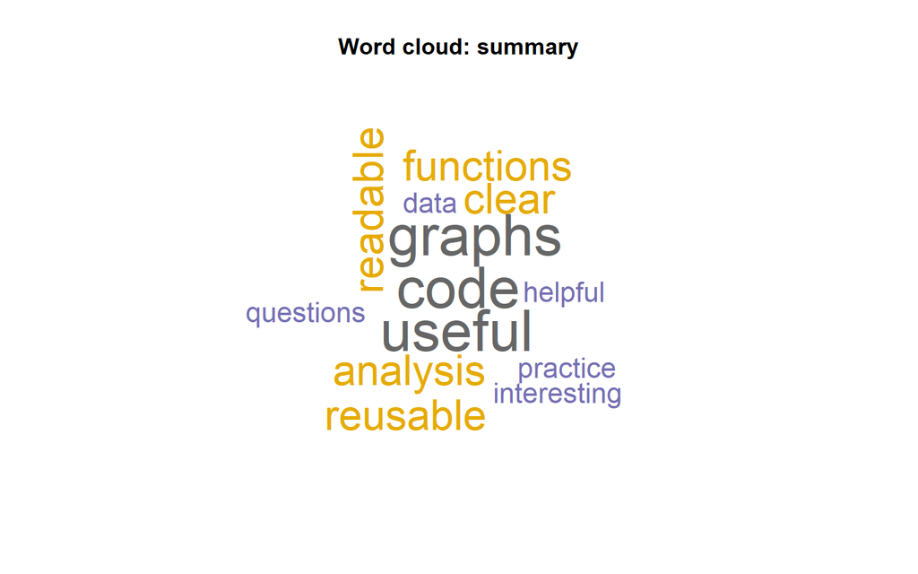

```r
text_wordcloud(reviews, "summary")
```

`input_data[[text_col]]` selects the column whose name is supplied as a string. `unnest_tokens()` splits text into lowercase words. Common stop words are removed, the remaining words are counted, and the cloud displays frequent words at larger sizes. The two calls demonstrate using different text columns without rewriting the function.